# ECON6027: Assignment 1 (50 marks)

Submission format:

1. Original R script or R markdown file
2. HTML/PDF output (knit your script to an html/pdf file for submission)
3. .txt file of the standard deviational ellipses

```r
library(sf); library(tmap); library(aspace)
```

### Question 1

1. Load the “cycle_hire” dataset from the package “spData” which is a point dataset of cycle hire points in central London. (5 marks)

```r
# Load the dataset
cycle_sf = st_read(system.file("shapes/cycle_hire.geojson", package="spData"))
st_is_longlat(cycle_sf)
```

```
## [1] TRUE
```

2. Compute a “standard deviational ellipse” of the cycle hire points. (5 marks)

```r
# Apply a projection. I used the British National Grid
# Typically this step is compulsory before you run any calculations.
cycle_sf = cycle_sf %>% st_transform(27700)
tmap_leaflet(tm_shape(cycle_sf) + tm_dots())
```

[interactive chart not shown]

```r
# Standard deviational ellipse (using aspace 4.1.0)
cycle_sde = calc_sde(id=1, points=st_coordinates(cycle_sf))

# change the sde to sf linestring
(cycle_sde_sf = cycle_sde$LOCATIONS %>% st_as_sf(coords = c("x", "y"), crs=27700) %>%
    st_combine() %>% st_cast("LINESTRING"))
```

```
## Geometry set for 1 feature
## Geometry type: LINESTRING
## Dimension:     XY
## Bounding box:  xmin: 524505.2 ymin: 177040.4 xmax: 535222.9 ymax: 183343.6
## Projected CRS: OSGB36 / British National Grid
```

```
## LINESTRING (535146 182104.3, 535109 182195.4, 5...
```

```r
(cycle_sde_sf = st_sf(cycle_sde$ATTRIBUTES, geom=st_geometry(cycle_sde_sf)))
```

```
## Simple feature collection with 1 feature and 19 fields
## Geometry type: LINESTRING
## Dimension:     XY
## Bounding box:  xmin: 524505.2 ymin: 177040.4 xmax: 535222.9 ymax: 183343.6
## Projected CRS: OSGB36 / British National Grid
##   id CALCCENTRE weighted CENTRE.x CENTRE.y Sigma.x  Sigma.y  Major  Minor
## 1  1       TRUE    FALSE 529864.2   180192 2664.29 5617.316 SigmaY SigmaX
##      Theta Eccentricity Area.sde TanTheta  SinTheta  CosTheta
## 1 70.09684    0.8803636 47017564 2.761994 0.9402694 0.3404314
##   SinThetaCosTheta Sin2Theta Cos2Theta ThetaCorr
## 1        0.3200972 0.8841065 0.1158935  70.09684
##                             geom
## 1 LINESTRING (535146 182104.3...
```

3. Plot both hire points and the ellipse on an interactive map using the leaflet driver “OpenStreetMap”. (5 marks)

```r
# interactive map
tmap_mode("view")
```

```
## tmap mode set to interactive viewing
```

```r
tm_shape(cycle_sf) + tm_dots() +
  tm_shape(cycle_sde_sf) + tm_lines(col="red", lwd=2) +
  tm_layout(main.title = "Cycle Hire Locations in Central London") +
  tm_basemap(server = "OpenStreetMap")
```

[interactive chart not shown]

```r
tmap_mode("plot")
```

```
## tmap mode set to plotting
```

Don’t forget to clear the environment before you proceed.

```r
rm(list=ls())
```

### Question 2

The “quakes” data.frame (an inbuilt dataset in R) that gives the locations of 1000 seismic events of MB > 4.0. The events occurred in a cube near Fiji since 1964.

1. Give spatial awareness to this dataset. The coordinate reference system should use the world geodetic system. Generate the head of your dataset. (5 marks)

```r
# inspect data
data(quakes); head(quakes)
```

```
##      lat   long depth mag stations
## 1 -20.42 181.62   562 4.8       41
## 2 -20.62 181.03   650 4.2       15
## 3 -26.00 184.10    42 5.4       43
## 4 -17.97 181.66   626 4.1       19
## 5 -20.42 181.96   649 4.0       11
## 6 -19.68 184.31   195 4.0       12
```

```r
# main
quakes_sf = st_as_sf(quakes, coords=c("long","lat"))
st_crs(quakes_sf) = 4326 # it is known that the dataset follows the WGS84.
quakes_sf
```

```
## Simple feature collection with 1000 features and 3 fields
## Geometry type: POINT
## Dimension:     XY
## Bounding box:  xmin: 165.67 ymin: -38.59 xmax: 188.13 ymax: -10.72
## Geodetic CRS:  WGS 84
## First 10 features:
##    depth mag stations              geometry
## 1    562 4.8       41 POINT (181.62 -20.42)
## 2    650 4.2       15 POINT (181.03 -20.62)
## 3     42 5.4       43     POINT (184.1 -26)
## 4    626 4.1       19 POINT (181.66 -17.97)
## 5    649 4.0       11 POINT (181.96 -20.42)
## 6    195 4.0       12 POINT (184.31 -19.68)
## 7     82 4.8       43   POINT (166.1 -11.7)
## 8    194 4.4       15 POINT (181.93 -28.11)
## 9    211 4.7       35 POINT (181.74 -28.74)
## 10   622 4.3       19 POINT (179.59 -17.47)
```

2. Prepare two interactive maps of the recorded “magnitude” and depth of the “location” using “tmap” package. (5 marks)

```r
tmap_mode("view")
```

```
## tmap mode set to interactive viewing
```

```r
tm_shape(quakes_sf) + tm_dots(col="mag", title = "magnitude")
```

[interactive chart not shown]

```r
tm_shape(quakes_sf) + tm_dots(col="depth")
```

[interactive chart not shown]

```r
tmap_mode("plot")
```

```
## tmap mode set to plotting
```

3. Compute the (i) mean centre, and (ii) the standard deviational ellipse using “magnitude” attribute as weights. (5 marks)

```r
# Descriptive measures cannot be computed using geographic CRS
# Change the CRS from geographic to projected using UTM
# Fiji 1956 / UTM zone 60S - EPSG:3141.
quakes_sf = st_transform(quakes_sf, crs=3141)
coords = st_coordinates(quakes_sf)
mag = quakes_sf$mag

# (i) mean centre
fiji_mean = calc_mnc(id=2, weighted = T, weights=mag, points=coords)
(fiji_mean_sf = st_as_sf(fiji_mean$ATTRIBUTES, coords = c("CENTRE.x", "CENTRE.y"), crs=3141))
```

```
## Simple feature collection with 1 feature and 1 field
## Geometry type: POINT
## Dimension:     XY
## Bounding box:  xmin: 739436.2 ymin: 7702581 xmax: 739436.2 ymax: 7702581
## Projected CRS: Fiji 1956 / UTM zone 60S
##   id                 geometry
## 1  2 POINT (739436.2 7702581)
```

```r
# (ii) SDE
fiji_sde = calc_sde(id=1, weighted = T, weights=mag, points=coords)
(fiji_sde_sf = fiji_sde$LOCATIONS %>%
    st_as_sf(coords = c("x", "y"), crs=3141) %>% st_combine() %>%
    st_cast("LINESTRING"))
```

```
## Geometry set for 1 feature
## Geometry type: LINESTRING
## Dimension:     XY
## Bounding box:  xmin: -184471.5 ymin: 6913105 xmax: 1663394 ymax: 8492046
## Projected CRS: Fiji 1956 / UTM zone 60S
```

```
## LINESTRING (1587152 7150665, 1596517 7165689, 1...
```

```r
(fiji_sde_sf = st_sf(fiji_sde$ATTRIBUTES, geom=st_geometry(fiji_sde_sf)))
```

```
## Simple feature collection with 1 feature and 19 fields
## Geometry type: LINESTRING
## Dimension:     XY
## Bounding box:  xmin: -184471.5 ymin: 6913105 xmax: 1663394 ymax: 8492046
## Projected CRS: Fiji 1956 / UTM zone 60S
##   id CALCCENTRE weighted CENTRE.x CENTRE.y  Sigma.x Sigma.y  Major  Minor
## 1  1       TRUE     TRUE 739436.2  7702581 673606.3 1011550 SigmaY SigmaX
##      Theta Eccentricity    Area.sde  TanTheta  SinTheta   CosTheta
## 1 123.0666    0.7460278 2.14064e+12 -1.535951 0.8380366 -0.5456141
##   SinThetaCosTheta Sin2Theta Cos2Theta ThetaCorr
## 1       -0.4572445 0.7023053 0.2976947  123.0666
##                             geom
## 1 LINESTRING (1587152 7150665...
```

4. Plot the output of (c) on a static map. Give an appropriate title (5 marks)

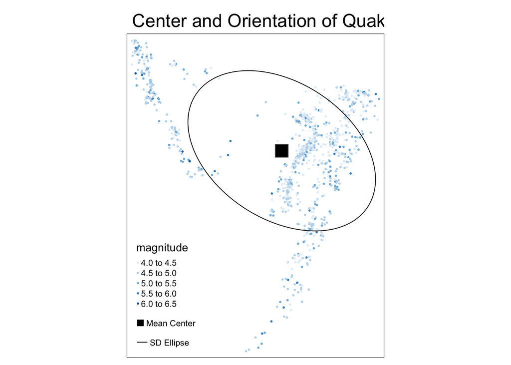

```r
# plot
tm_shape(quakes_sf) + tm_dots(col="mag", title = "magnitude", palette="Blues") +
  tm_shape(fiji_mean_sf) + tm_squares(col="black") +
  tm_shape(fiji_sde_sf) + tm_lines(col="black") +
  tm_layout(main.title="Center and Orientation of Quakes") +
  tm_add_legend(type="symbol", col="black", labels="Mean Center", shape=15) +
  tm_add_legend(type="line", col="black", labels="SD Ellipse", lty=1)
```

```r
# notice how the orientation of the quakes is along the Australian and Pacific plate intersection.
```

Don’t forget to clear the environment before you proceed.

```r
rm(list=ls())
```

### Question 3

Variables (in order of appearance):

- Planning area name
- Total population (thousands)
- Percentage of population who are free thinkers
- Percentage of population with no literacy
- Percentage of population with tertiary education
- Percentage of population with only primary education
- Percentage of population in white collar jobs
- Total number of households (thousands)
- Average household size by residents
- Percentage of households with a combined income above the median national income
- Percentage of households with a combined income above $20,000
- Percentage of households with a combined income below $1,000
- Percentage of households that are owner occupied
- Percentage of HDBs

```r
library(dplyr)
```

1. Load the “sg_house.csv” dataset to R using the read.csv() function. Read the Singapore planning area shapefile from Chapter 1 (shared for your convenience). Combine the two datasets (using an appropriate method). The final object should be an sf object. Your uploaded answer should include a compressed folder of this combined sf object saved as a shapefile. (5 marks)

```r
sg_house = read.csv("sg_house.csv")
class(sg_house)
```

```
## [1] "data.frame"
```

```r
# setwd("C:/Users/sfliu/Dropbox/MSc/Lessons/1 Introduction")
sg_PA = st_read("MP14_PLNG_AREA_WEB_PL.shp")
table(st_is_valid(sg_PA)) # 8 false entries
```

```
##
## FALSE  TRUE
##     8    47
```

```r
# It is always a good idea to check the validity of the object before proceeding.
# If there are FALSE entries, use st_make_valid to validate the object.
sg_PA = st_make_valid(sg_PA); table(st_is_valid(sg_PA))
```

```
##
## TRUE
##   55
```

```r
# next time directly the run the following command.
# sg_PA = st_read("MP14_PLNG_AREA_NO_SEA_PL.shp") %>% st_make_valid()

sg_house_sf = inner_join(sg_house, sg_PA)
class(sg_house_sf) # is it an sf object?
```

```
## [1] "data.frame"
```

```r
(sg_house_sf = st_as_sf(sg_house_sf))
```

```
## Simple feature collection with 55 features and 25 fields
## Geometry type: GEOMETRY
## Dimension:     XY
## Bounding box:  xmin: 2667.538 ymin: 15748.72 xmax: 56396.44 ymax: 50256.33
## Projected CRS: SVY21
## First 10 features:
##                 PLN_AREA_N TOT_POP PCT_FREE PCT_ILLIT PCT_TERTIARY   PCT_PRI
## 1               ANG MO KIO   164.4 17.11196 4.8346056     31.33609 25.688705
## 2                    BEDOK   252.2 15.81178 3.7727851     36.14118 19.670588
## 3                   BISHAN    82.1 22.14941 2.0969856     44.64023 13.656388
## 4                 BOON LAY      NA       NA        NA           NA        NA
## 5              BUKIT BATOK   128.2 17.23564 2.5811823     35.07605 18.536122
## 6              BUKIT MERAH   133.5 19.84906 5.6603774     31.62602 26.666667
## 7            BUKIT PANJANG   134.4 17.55853 3.0100334     32.67790 19.194757
## 8              BUKIT TIMAH    65.5 25.38071 0.5076142     67.87072  5.703422
```

[output cut: 46 more lines]

```r
class(sg_house_sf) # check again...
```

```
## [1] "sf"         "data.frame"
```

```r
# Create a shapefile of the object
st_write(sg_house_sf, "sg_house.shp", delete_layer=T)
```

```
## Deleting layer `sg_house' using driver `ESRI Shapefile'
## Writing layer `sg_house' to data source
##   `sg_house.shp' using driver `ESRI Shapefile'
## Writing 55 features with 25 fields and geometry type Unknown (any).
```

2. Generate a plot (using tmap) of the attribute, percentage of households above median income given by “PCT_ABOVEMEDIN”. Your map should, (5 marks)
1. Include an appropriate title
2. Use the quartiles as the “breaks”
3. Change the line type to “dotted”.

```r
summary(sg_house_sf$PCT_ABOVEMEDIN) # check quartiles
```

```
##    Min. 1st Qu.  Median    Mean 3rd Qu.    Max.    NA's
##   34.52   43.04   50.00   51.10   58.95   73.22      24
```

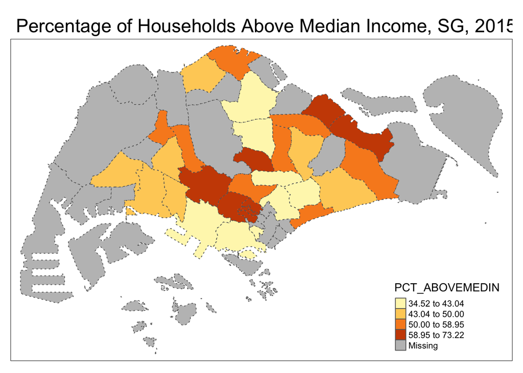

```r
bins = c(34.52, 43.04, 50, 58.95, 73.22)
tm_shape(sg_house_sf) + tm_polygons(col="PCT_ABOVEMEDIN", breaks=bins, lty=3) +
  tm_layout(main.title = "Percentage of Households Above Median Income, SG, 2015")
```

```r
# plot(sg_house_sf["PCT_ABOVEMEDIN"], breaks=bins, lty=3,
#     main="Percentage of Households Above Median Income, Singapore, 2015")
```

3. Extract the central region and create a new spatial object. Create a subset of planning areas in the central region that has more than half the households listed as HDBs. (5 marks)

```r
(central_sg = sg_house_sf[sg_house_sf$REGION_C == "CR", ]) # Extract central region
```

```
## Simple feature collection with 22 features and 25 fields
## Geometry type: GEOMETRY
## Dimension:     XY
## Bounding box:  xmin: 18752.4 ymin: 21678.35 xmax: 37592.2 ymax: 38891.37
## Projected CRS: SVY21
## First 10 features:
##       PLN_AREA_N TOT_POP PCT_FREE PCT_ILLIT PCT_TERTIARY   PCT_PRI
## 3         BISHAN    82.1 22.14941 2.0969856     44.64023 13.656388
## 6    BUKIT MERAH   133.5 19.84906 5.6603774     31.62602 26.666667
## 8    BUKIT TIMAH    65.5 25.38071 0.5076142     67.87072  5.703422
## 14 DOWNTOWN CORE      NA       NA        NA           NA        NA
## 15       GEYLANG    93.8 19.58874 4.5454545     32.31132 23.820755
## 19       KALLANG    83.4 21.22642 5.5424528     36.39847 24.265645
## 22   MARINA EAST      NA       NA        NA           NA        NA
## 23  MARINA SOUTH      NA       NA        NA           NA        NA
```

[output cut: 46 more lines]

```r
(central_hdb = subset(central_sg, PCT_HDB > 50))
```

```
## Simple feature collection with 7 features and 25 fields
## Geometry type: POLYGON
## Dimension:     XY
## Bounding box:  xmin: 18752.4 ymin: 26375.86 xmax: 36167.34 ymax: 38891.37
## Projected CRS: SVY21
##     PLN_AREA_N TOT_POP PCT_FREE PCT_ILLIT PCT_TERTIARY  PCT_PRI PCT_WCOLLAR
## 3       BISHAN    82.1 22.14941  2.096986     44.64023 13.65639    47.87879
## 6  BUKIT MERAH   133.5 19.84906  5.660377     31.62602 26.66667    32.84672
## 15     GEYLANG    93.8 19.58874  4.545455     32.31132 23.82075    32.57329
## 19     KALLANG    83.4 21.22642  5.542453     36.39847 24.26564    36.64260
## 30      OUTRAM    16.0 23.56322  8.045977     35.97561 23.78049    31.62393
## 35  QUEENSTOWN    79.8 20.17115  4.767726     37.43316 22.05882    39.83740
## 50   TOA PAYOH   108.9 20.11121  4.170528     33.06205 23.80468    34.54282
##    TOT_HOUSEHOLDS AVG_HOUSEHOLD PCT_ABOVEMEDIN PCT_ABOVE20K PCT_BELOW1K
## 3            27.8      3.449640       60.79137    19.784173    11.15108
```

[output cut: 30 more lines]

```r
# Codes may generally differ and that is OK!
```